# hw5

Ekaterina Uetova

```r
library(tidyverse)
library(GGally)
library(ca)
```

### 1.1

Скачайте датасет `chairs`, в котором собраны разные описания экземпляров из немецких он-лайн каталогов, отнесенным к категориям *Stuhl* ‘стул’ or *Sessel* ‘кресло’. В датасете 19 переменных:

- `Shop` a factor that describes the online store with levels ikea.de, Moebel-Profi.de and roller.de.
- `WordDE` a factor that describes the specific lexical category.
- `Category` a factor that describes the more general lexical category (usually the last element of a composite noun), with levels Sessel and Stuhl.
- `Function` a factor with levels Eat, NotSpec, Outdoor, Relax and Work.
- `Age` a factor with levels Adult and Children.
- `Back` a factor with levels Adjust, High, Low and Mid.
- `Soft` a factor with levels No, Pad and Yes.
- `Arms` a factor with levels No and Yes.
- `Upholst` a factor with levels No and Yes.
- `MaterialSeat` a factor with levels Fabric, Leather, Loom_natur, Metal, Paper, Plastic, Polyamide, Rattan, Steel and Wood.
- `SeatHeight` a factor with levels Adjust, High and Norm.
- `SeatDepth` a factor with levels Adjust, Deep and Norm.
- `Swivel` a factor with levels No and Yes
- `Roll` a factor with levels No and Yes.
- `Rock` a factor with levels No and Rock.
- `AddFunctions` a factor with levels Bed, No and Table.
- `Recline` a factor with levels No and Yes.
- `ReclineBack` a factor with levels No and Yes.
- `SaveSpace` a factor with levels collapse, No and stack.

Используйте все переменные кроме переменных `Shop`, `WordDE` и `Category`, чтобы построить MCA. Нарисуйте все наблюдения, раскрасьте их по переменной `Category` и добавьте доверительные эллипсы. Сверху нанесите переменные из получившейся модели MCA. Получившийся график `ggplot` запустите в консоль.

```r
df <- read.csv('https://raw.githubusercontent.com/euetova/2018_hse_data_analysis/master/hw5_CA_MCA/hw5_chairs.csv')

MCA <- MASS::mca(df[, 4:19])

df <- cbind(df, MCA$rs)
variables <- as_data_frame(MCA$cs)
variables$var_names <- rownames(MCA$cs)
df %>%
  ggplot(aes(`1`, `2`))+
  geom_point(aes(color = Category))+
  stat_ellipse(aes(color = Category))+
  geom_text(data = variables, aes(`1`, `2`, label = var_names), size=3)+
  theme_bw()+
  scale_x_continuous(limits = c(-0.015, 0.02))
```

[output not shown]

### 1.2

Проанализируйте полученные результаты. Что Вы можете сказать на основе полученных результатов про категории `Stuhl` и `Sessel` в немецком? Что Вы можете сказать про переменные?

> Stuhl и Sessel довольно хорошо разделяются. У Stuhl гораздо больше разброс во внешнем виде и в применении, чем у Sessel (Sessel в основном сделан из ткани и кожи и предназначен для отдыха/сна).

### 2.1

Cкачайте данные, содержащие 11 базовых цветов в разных подкорпусах Corpus of Contemporary American English (Davies 2008 - ). Учитывались только адъективные употребления. Постройте CA и нарисуйте биплот с переменными из столбцов и строчек (без стрелочек). Получившийся график `ggplot` запустите в консоль.

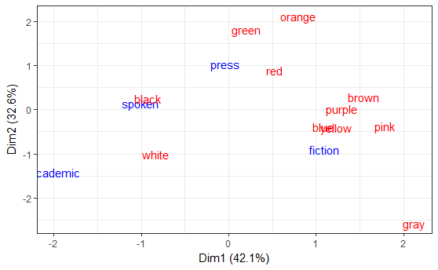

```r
df2 <- read.csv('https://raw.githubusercontent.com/euetova/2018_hse_data_analysis/master/hw5_CA_MCA/hw5_colreg.csv')
rownames(df2) <- df2$colors
ca <- ca(df2[,-5])
color_col <- data.frame(ca$colcoord)
color_col$rows <- rownames(ca$colcoord)
color_row <- data.frame(ca$rowcoord)
color_row$rows <- rownames(ca$rowcoord)
color_col %>%
  ggplot(aes(Dim1, Dim2, label = rows))+
  geom_text(color = "blue")+
  geom_text(data = color_row, color = "red")+
  theme_bw()+
  labs(x = "Dim1 (42.1%)",
       y = "Dim2 (32.6%)")
```

### 2.2

Проинтерпретируйте полученные результаты.

> Для academic характерен только цвет white. В spoken очень часто употребляется цвет black, режеwhite. green, red и orange свойственны для press. Больше всего цветов в fiction - blue, yellow, purple, brown, pink и gray (4, видимо, редкое название цвета, которое иногда встречается в fiction).